# Assignment 9: Hypothesis Testing and Power and Sample size Determination

Josie Gallop

Due: 4-7-26

## **Assignment Objectives**

- Enhance understanding the logic and procedure of hypothesis testing .
- Implement the procedures for power and sample size calculation for basic hypothesis testing procedures using nuilt-in function and manual calculation.

## **Policies of Using AI Tools**

**Policy on AI Tool Use**: Please adhere to the AI tool policy specified in the course syllabus. The direct copying of AI-generated content is strictly prohibited. All submitted work must reflect your own understanding; where external tools are consulted, content must be thoroughly rephrased and synthesized in your own words.

**Code Inclusion Requirement**: Any code included in your essay must be properly commented to explain the purpose and/or expected output of key code lines. Submitting AI-generated code without meaningful, student-added comments will not be accepted.

## **Simple versus Composite Hypothesis*

**Simple Hypothesis**

- **Simple Hypothesis Test** is a hypothesis that completely specifies the population distribution. Mathematically, simple hypothesis fixes all parameters to specific values. For example, The simple hypotheses are: $H_0: \mu = 5$ (if $\alpha$ is known), $H_0: \mu = 100, \sigma^2 = 25$, and $H_1: p = 0.7$ for a Bernoulli distribution.
- **Example Scenario** Test if a coin is fair:

$$\begin{aligned}
H_0&: p = 0.5 \quad \text{(completely specified)} \\
H_1&: p = 0.6 \quad \text{(also completely specified)}
\end{aligned}$$

Both are **simple** hypotheses.

**Composite Hypothesis**

- **Composite Hypothesis** is a hypothesis that does not completely specify the distribution. Mathematically, it allows a range of values for at least one parameter. For example, in one-sided: $\mu >5$; in two-sided: $\mu \le 5$.
- **Example Scenarios**

$$\begin{aligned}
&H_0: \mu = 5 && \text{(simple)} \\
&H_1: \mu > 5 && \text{(composite)}
\end{aligned}$$
$$\begin{aligned}
&H_0: \mu \leq 5 && \text{(composite)} \\
&H_1: \mu > 5 && \text{(composite)}
\end{aligned}$$
$$\begin{aligned}
&H_0: \text{data follows } N(\mu, 1), \mu = 0 &&
\text{(simple)} \\
&H_1: \text{data follows Poisson}(\lambda) &&
\text{(composite – different family)}
\end{aligned}$$

**This assignment focuses on performing performing a test of mean ($\mu$) a normal population and calculating the power and sample size based on various assumptions**

## **Question: New Cholesterol Medication**

A pharmaceutical company develops **“CholestFix”** to reduce Low-Density Lipoprotein (LDL, *fat carrier that’s low in density*) cholesterol. The **current standard drug** lowers LDL by an average of 25 mg/dL with a standard deviation of 15 mg/dL. A clinical trial with 5 participants were recruited in the study for three months. At the end of the study, the mean reduction is 29 mg/dL. Assume that the variance of LDL reduction of new drug is the same as that of the standard drugs.

Based on the results in the clinical trial, researchers in the company believe **CholestFix** is more effective.

a). Perform a formal hypothesis test of the researchers’ belief regarding LDL reduction, using a significance level of $\alpha = 0.05$.

We are interested in testing whether the new drug, CholestFix, lowers LDL cholesterol a significantly greater amount than the current standard drug. The hypotheses are as follows: $H_0: \mu = 25$ (simple) $H_1: \mu > 25$ (composite) In this case, $H_0$ is the simple hypothesis and $H_1$ is the composite hypothesis. We are given the following information: $\bar{x} = 29$, $\sigma = 15$, and $n = 5$. Since $\sigma$ is known, a z-test will be used as opposed to a t-test. However, it is worth noting that the sample size of $ n = 5$ is very small. I will begin by calculating the z-score as follows, $z = \frac{\bar{x} - \mu_0}{\sigma / \sqrt{n}} = \frac{29 - 25}{15 / \sqrt{5}} \approx 0.596$. Now that I have the z-score along with all the other neccessary information, I will write an R function to conduct my hypothesis test of whether the new drug named CholestFix lowers LDL cholesterol a significantly greater amount than the existing drug.

```r
# Given information
xbar <- 29
mu0 <- 25
sigma <- 15
n <- 5

# Calculate z-score and find p value
z <- (xbar - mu0) / (sigma / sqrt(n))
p_value <- 1 - pnorm(z)

p_value
```

```
[1] 0.2754925
```

At the $\alpha = 0.05$ significance level, there is not sufficient evidence to reject the null hypothesis, p = 0.2755. Therefore, we fail to reject $H_0$ and conclude that there is not sufficient evidence to conclude that CholestFix lowers LDL cholesterol a greater amount than the existing drug.

This analysis and these finding are valid because we assume that the LDL cholesterol reduction is normally distributed and the population standard deviation is known, $\sigma = 15$. This justifies the use of a z-test. Additionally, the observations are assumed to be independent. However, the small sample size of $n = 5$ may limit the reliability of the results.

b). Given $n = 50, \sigma = 15, \alpha = 0.05$, and an effect size we wish to detect $\delta = 4$ mg/dL (corresponding to a reduction from 29 mg/dL to 25 mg/dL). What is the probability that we’d detect a true improvement?

Next, given that now $n = 50, \sigma = 15$, and $\alpha = 0.05$, we also have $\delta = 4$, which is the effect size we wish to detect. I will calculate the probability that we would detect a true improvement from the existing drug to the new CholestFix drug in lowering LDL cholesterol.

I will write an R function to calculate the power and use it to find the probability that we would detect a true improvement, for this given scenario.

```r
# Power calculation
n <- 50
sigma <- 15
delta <- 4
alpha <- 0.05

z_alpha <- qnorm(1 - alpha)

power <- 1 - pnorm(z_alpha - (delta * sqrt(n) / sigma))
power
```

```
[1] 0.5951312
```

The power is 0.595, or 59.5%. This means that even if CholestFix is actually better than the original drug by 4 mg/dL, with a sample size of 50, we would only have a 59.5% chance of finding a statistically significant result. This falls below the commonly desired power level of 0.80, indicating that this study may not be adequately powered to reliably detect the effect. So, we can conclude that this study is underpowered.

This relatively low power also indicates a high probability of a Type II error, which is something that we would like to avoid as a Type II error in this case would mean failing to reject the null hypothesis when we really should have. This would mean failing to conclude that the CholestFix drug lowers LDL cholesterol a significantly greater amount than the existing drug even when it truly does. Such an error would be quite bad as it would mean that patients would be missing out on a potential treatment that could help them. Therefore, it would be a good idea to focus on increasing the power, as a power of 0.595 means we only have a 59.5% chance of avoiding such a Type II error, which is not a reliable percentage.

c). Determine the minimum sample size required to detect an effect size of 4 mg/dL with a power of $1 - \beta = 0.8$ and a significance level of $\alpha = 0.05$. Assume the standard deviation of LDL reduction is 15 mg/dL.

Now, I will find the minimum sample size that would be required to detect an effect size of 4 mg/dL with a power of 0.8 at the $\alpha = 0.05$ significance level. I will use the following formula to calculate n, the sample size. $n = \left(\frac{(z_{1-\alpha} + z_{1-\beta})\,\sigma}{\delta}\right)^2$. Here, $z_{1-\alpha}$ corresponds to the critical value of the test, and $z_{1-\beta}$ corresponds to the desired power. I will round the number that I get up to the next nearest whole number, as this will be the true sample size required to make sure everything is adequately accounted for.

```r
sigma <- 15
delta <- 4
alpha <- 0.05
power_target <- 0.8

z_alpha <- qnorm(1 - alpha)
z_beta <- qnorm(power_target)

# Calculate the number required and round up to the next nearest whole number
n_required <- ((z_alpha + z_beta) * sigma / delta)^2
n_required
```

```
[1] 86.94221
```

```r
ceiling(n_required)
```

```
[1] 87
```

A sample size of 87 would be the minimum sample size required to detect an effect size of 4 mg/dL with a power of $1 - \beta = 0.8$, and a significance level of $\alpha = 0.05$, assuming that the standard deviation of LDL reduction is 15 mg/dL. Therefore, we would need to have at least 87 individuals in the sample to detect this desired effect size. This ensures that the study has a sufficiently high probability of detecting a meaningful improvement in LDL cholesterol reduction, if one truly exists.

d). **Power curve**: To assess the impact of sample size on power, we can create a power function in terms of the sample size $n$ and use the remaining information from part (b). Plot the power curve by selecting a sequence of sample sizes.

I will create an R function to plot the power curve in terms of the sample size $n$ and the information that was found regarding power in part b. I will use a sequence of sample sizes to plot this power curve, and I will have this range of sample sizes go from 5, which was the original sample size in part a, up to a sample size of 150. I will also include a horizontal line at where power equals 0.8 or 80%, as this is the standard, desired power we want to see in a statistical model.

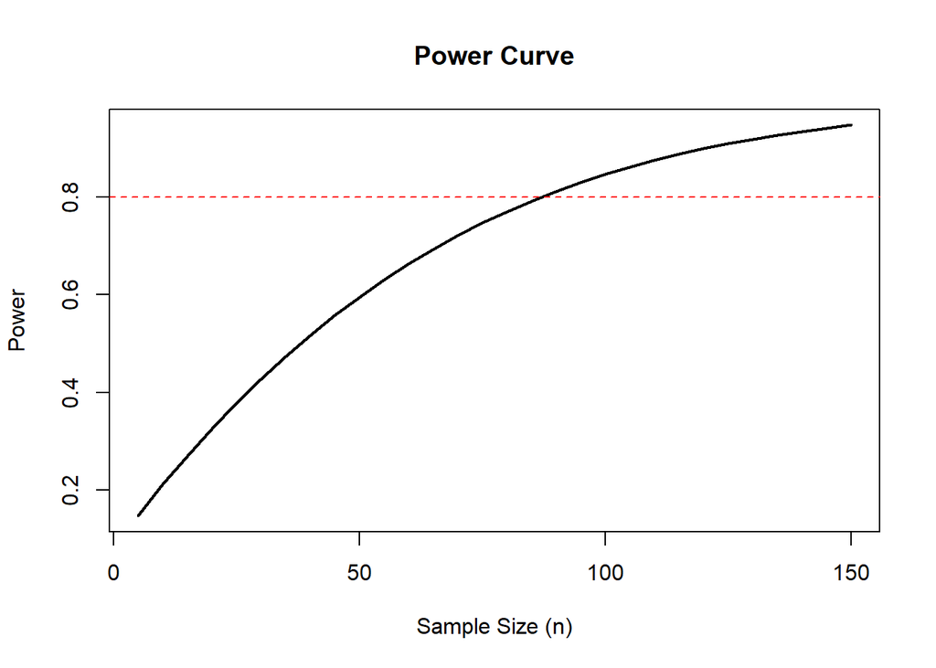

```r
sigma <- 15
delta <- 4
alpha <- 0.05

# Range of different sample sizes to show changes in power
n_seq <- seq(5, 150, by = 5)

# Calculate the power
power_vals <- sapply(n_seq, function(n) {
  z_alpha <- qnorm(1 - alpha)
  1 - pnorm(z_alpha - (delta * sqrt(n) / sigma))
})

# Plot the power curve
plot(n_seq, power_vals, type = "l", lwd = 2,
     xlab = "Sample Size (n)",
     ylab = "Power",
     main = "Power Curve")

abline(h = 0.8, col = "red", lty = 2)
```

As the sample size increases, so does the power. In the power curve it can be seen that at the highest included sample size of 150, the power grows very close to 1. This would mean a very low chance of committing a Type II error due to such high power. However, a large sample size can be difficult in reality due to time and money constraints. In fact, looking at the power curve it can be seen that the power reaches 0.8 or 80% at a sample size of 87, which was found in part c as well. This indicates that a sample size of 87 would be sufficient in terms of power, as 80% power is the widely accepted statistical standard.